# Project 1

Author

Björn Ahl, Leon Krasniqi, Nora Granström

Published

April 29, 2026

## Setup

```r
library(tidyverse)
library(readxl)
library(car)
library(rstatix)
library(GGally)
xlsx_path <- if (file.exists("Project1data.xlsx")) "Project1data.xlsx" else "/Users/bjorn_ahl/Downloads/GitHub/MASM22/Project_1/Project1data.xlsx"
df <- as.data.frame(read_excel(xlsx_path))
```

# Part 1. Particle emissions and fuel consumption

## 1(a) Choice of transformations

We compare three candidate models: `PM10 ~ Fuel`, `log(PM10) ~ Fuel`, `log(PM10) ~ log(Fuel)` and the comparison is mainly based on residual and Q-Q plots.

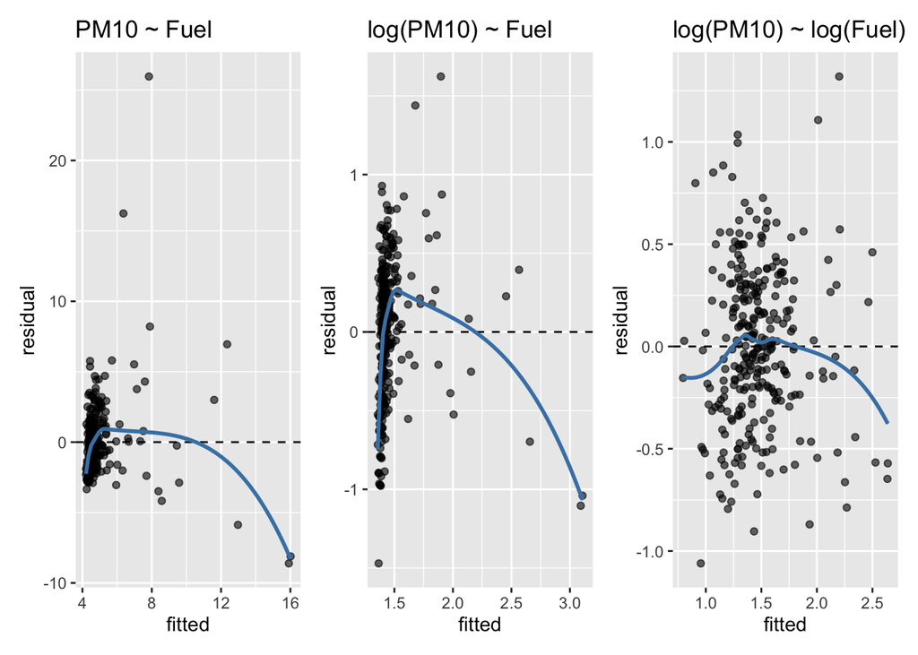

Figure 1: Residuals vs fitted for PM10~Fuel, log(PM10)~Fuel, and log(PM10)~log(Fuel).

```r
library(broom)
library(patchwork)

m_raw    <- lm(PM10      ~ Fuel,       data = df)
m_logy   <- lm(log(PM10) ~ Fuel,       data = df)
m_loglog <- lm(log(PM10) ~ log(Fuel),  data = df)

plot_resid <- function(mod, title) {
  augment(mod) |>
    ggplot(aes(.fitted, .resid)) +
    geom_point(alpha = .6) +
    geom_hline(yintercept = 0, linetype = 2) +
    geom_smooth(se = FALSE, method = "loess", formula = y ~ x, colour = "steelblue") +
    labs(title = title, x = "fitted", y = "residual")
}

plot_resid(m_raw,    "PM10 ~ Fuel") +
  plot_resid(m_logy,   "log(PM10) ~ Fuel") +
  plot_resid(m_loglog, "log(PM10) ~ log(Fuel)")
```

**Interpretation:**

- **Linear relationship.** In this case we have PM10 = x₀ + x₁·Fuel. From the graph we observe a stronger tendency toward the left, meaning observations cluster at lower fuel values while the spread of PM10 widens with Fuel. This suggests a purely linear model is not sufficient.
- **Logarithmic response.** ln(PM10) = x₀ + x₁·Fuel is equivalent to PM10 = $a\cdot b^{Fuel}$. The residual plot is less skewed, but equal additive changes in Fuel are treated the same across the scale, which is unrealistic for municipalities of different sizes.
- **Log-log relationship.** ln(PM10) = x₀ + x₁·ln(Fuel) implies PM10 = a·Fuel^x₁. A relative change in Fuel implies a relative change in PM10, and the residuals are more evenly spread. This makes the log-log transformation the most plausible choice.

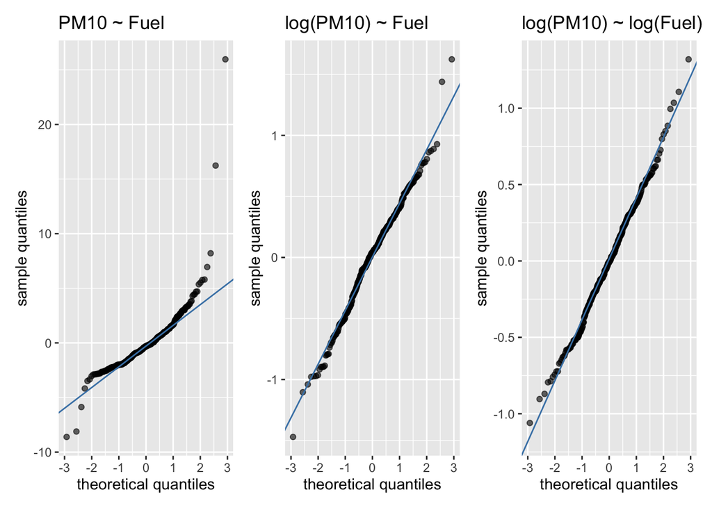

Figure 2: QQ-plots of residuals for PM10~Fuel, log(PM10)~Fuel, and log(PM10)~log(Fuel).

```r
plot_qq <- function(mod, title) {
  augment(mod) |>
    ggplot(aes(sample = .resid)) +
    stat_qq(alpha = .6) +
    stat_qq_line(colour = "steelblue") +
    labs(title = title, x = "theoretical quantiles", y = "sample quantiles")
}
plot_qq(m_raw,    "PM10 ~ Fuel") +
    plot_qq(m_logy,   "log(PM10) ~ Fuel") +
    plot_qq(m_loglog, "log(PM10) ~ log(Fuel)")
```

From the QQ-plots we can clearly see that the log–log transformation gives the best fit, as its residuals follow the reference line most closely and are therefore the most normally distributed of the three.

## 1(b) Confidence interval, prediction interval and $\beta$-estimates

In this part-question, we obtain the $\beta$-estimates and their 95% confidence intervals when `x = ln(Fuel)`.

```r
another_model <- lm(log(PM10) ~ log(Fuel), data = df)
another_model$coefficients
```

```
(Intercept)   log(Fuel)
  0.2924625   0.3769139
```

```r
confint(another_model)
```

```
                2.5 %    97.5 %
(Intercept) 0.1108545 0.4740705
log(Fuel)   0.3207491 0.4330787
```

```r
new_data <- data.frame(Fuel = seq(min(df$Fuel), max(df$Fuel), length.out = 100))

pred_int <- predict(another_model, newdata = new_data, interval = "prediction")
conf_int <- predict(another_model, newdata = new_data, interval = "confidence")

plot_df <- data.frame(
  Fuel = new_data$Fuel,
  fit = conf_int[, "fit"],
  ci_lower = conf_int[, "lwr"],
  ci_upper = conf_int[, "upr"],
  pi_lower = pred_int[, "lwr"],
  pi_upper = pred_int[, "upr"]
)

# Plot on log scale
p1 <- ggplot() +
  geom_point(data = df, aes(x = log(Fuel), y = log(PM10))) +
  geom_ribbon(data = plot_df, aes(x = log(Fuel), ymin = pi_lower, ymax = pi_upper),
              alpha = 0.2, fill = "blue") +
  geom_ribbon(data = plot_df, aes(x = log(Fuel), ymin = ci_lower, ymax = ci_upper),
              alpha = 0.4, fill = "blue") +
  geom_line(data = plot_df, aes(x = log(Fuel), y = fit), color = "red") +
  labs(x = "ln(Fuel)", y = "ln(PM10)",
       title = "Log scale: ln(PM10) ~ ln(Fuel)",
       subtitle = "red = fit, dark band = 95% CI, light band = 95% PI") +
  theme_minimal()

# Transforming back to original scale
plot_df_e <- data.frame(
  Fuel = new_data$Fuel,
  fit = exp(conf_int[, "fit"]),
  ci_lower = exp(conf_int[, "lwr"]),
  ci_upper = exp(conf_int[, "upr"]),
  pi_lower = exp(pred_int[, "lwr"]),
  pi_upper = exp(pred_int[, "upr"])
)

p2 <- ggplot() +
  geom_point(data = df, aes(x = Fuel, y = PM10)) +
  geom_ribbon(data = plot_df_e, aes(x = Fuel, ymin = pi_lower, ymax = pi_upper),
              alpha = 0.2, fill = "blue") +
  geom_ribbon(data = plot_df_e, aes(x = Fuel, ymin = ci_lower, ymax = ci_upper),
              alpha = 0.4, fill = "blue") +
  geom_line(data = plot_df_e, aes(x = Fuel, y = fit), color = "red") +
  labs(x = "Fuel", y = "PM10",
       title = "Original scale: PM10 vs Fuel (back-transformed)",
       subtitle = "red = fit, dark band = 95% CI, light band = 95% PI") +
  theme_minimal()

# Show both side by side so the log-scale and back-transformed versions are easy to compare
p1 + p2 + plot_annotation(title = "Model 1(b): ln(PM10) = beta0 + beta1 * ln(Fuel)")

# Back-transformed relationship: PM10 = exp(beta0) * Fuel^beta1 = a * Fuel^beta1
intercept <- cbind(
  expbeta = exp(another_model$coefficients["(Intercept)"]),
  exp(confint(another_model, parm = "(Intercept)"))
) |>
  round(digits = 4)

slope <- cbind(
  expbeta = exp(another_model$coefficients["log(Fuel)" ]),
  exp(confint(another_model, parm = "log(Fuel)"))
) |>
  round(digits = 4)

intercept   # a  = exp(beta0) with 95% CI
```

```
            expbeta  2.5 % 97.5 %
(Intercept)  1.3397 1.1172 1.6065
```

[output not shown]

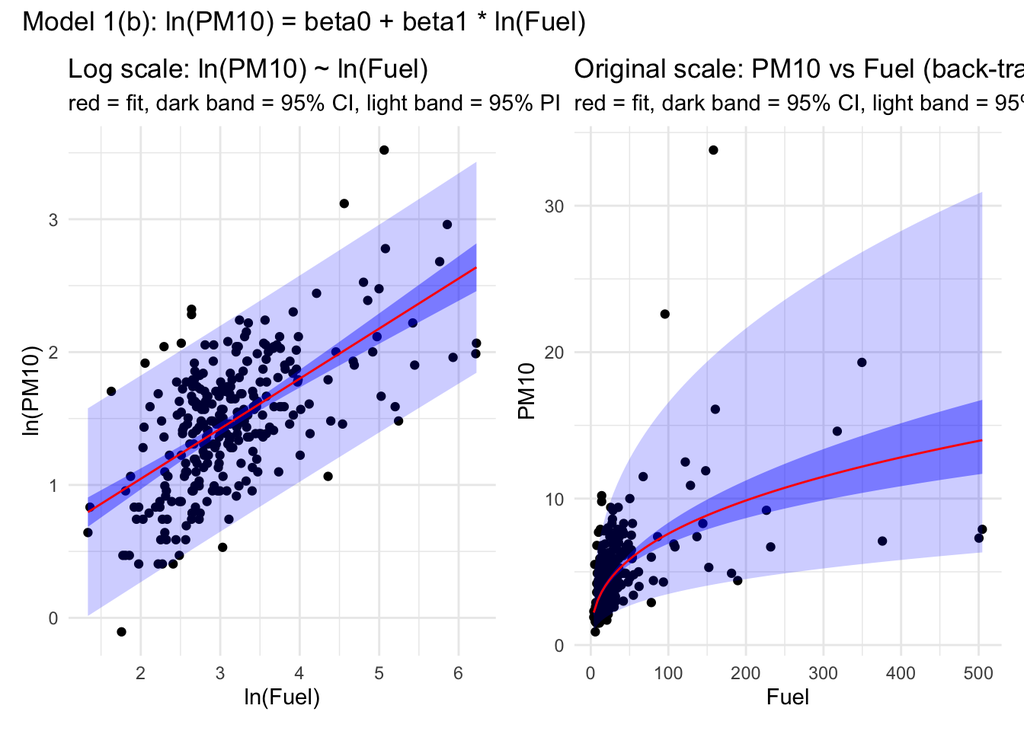

Figure 3

```r
slope       # exp(beta1) with 95% CI (the elasticity factor per unit change in log(Fuel))
```

**Back-transformation.** Exponentiating both sides of $\ln(\text{PM10}) = \beta_0 + \beta_1\ln(\text{Fuel})$ gives
$$\text{PM10} = e^{\beta_0}\cdot\text{Fuel}^{\beta_1} = a\cdot\text{Fuel}^{\beta_1}, \qquad a = e^{\beta_0}.$$

The plug-in estimates are $\widehat{a} = e^{\widehat{\beta}_0}$ (with 95 % CI $[\,e^{L_0},\,e^{U_0}\,]$) and $\widehat{\beta}_1$ with its usual CI — these are printed as `intercept` and `slope` above. Note that the CI/PI ribbons in the PM10 vs Fuel plot are the exponentials of the ribbons in the ln–ln plot, so they are valid intervals on the original scale but are no longer symmetric about the fit. Regarding any problems with model fitting, we need to look closely on residuals from figure 1. For residual plot of `log(PM10) ~ log(Fuel)`, we can see that it is relativly scatterad around the horizontal line. This indicates that we have fitted a model well. By looking at Q-Q plot for figure 2, we can see it follow the reference line well, which imply linearity assumptions hold. For residual plot of `PM10 ~ Fuel`, we can clearly see outliers (data points that are far away from others). This will effect model fitting, since it will predict less accurate in order to fit the extreme value (see figure 3). It also violate linearity assumptions, which can been observe from Q-Q plot.

## 1(c) Effect of changing fuel consumption

**Log–log model:**
$$\ln(\text{PM10}) = \beta_0 + \beta_1 \ln(\text{Fuel}) \;\Rightarrow\; \text{PM10 scales by } k^{\beta_1} \text{ if Fuel is multiplied by } k.$$

**10 % decrease in Fuel ($k=0.9$):**
$$r = 0.9^{\widehat{\beta}_1}.$$

If $\beta_1 \in [L,U]$, then
$$r \in [0.9^{U},\,0.9^{L}].$$

To reduce our PM10 to half of its original we get:
$$k^{\beta_1} = 0.5 \;\Rightarrow\; k = 0.5^{1/\beta_1} \implies \qquad \text{reduction} = (1 - 0.5^{1/\beta_1})\cdot 100.$$

$$k \in [0.5^{1/L},\,0.5^{1/U}], \implies \qquad \text{reduction} \in [1 - 0.5^{1/U},\,1 - 0.5^{1/L}]\cdot 100.$$

```r
b1  <- coef(another_model)["log(Fuel)"]
ci  <- confint(another_model, parm = "log(Fuel)")
L   <- ci[1]; U <- ci[2]

# (i) 10 % decrease in Fuel
r_hat <- 0.9^b1
r_ci  <- c(0.9^U, 0.9^L)
pct_change <- (c(r_hat, r_ci) - 1) * 100

# (ii) fuel reduction to halve PM10
k_hat <- 0.5^(1/b1)
k_ci  <- c(0.5^(1/L), 0.5^(1/U))
reduction <- (1 - c(k_hat, k_ci[2], k_ci[1])) * 100

round(rbind(
  "PM10 change (%) from -10% Fuel" = pct_change,
  "Fuel reduction (%) to halve PM10" = reduction
), 2)
```

```
                                 log(Fuel)
PM10 change (%) from -10% Fuel       -3.89 -4.46 -3.32
Fuel reduction (%) to halve PM10     84.10 79.82 88.48
```

## 1(d) Testing of the model

We test $H_0: \beta_1 = 0$ vs $H_1: \beta_1 \neq 0$ with a two-sided t-test. Under $H_0$ the statistic is $t_{n-2} = t_{288}$.

```r
another_model_summary <- summary(another_model)
another_model_summary$coefficients
```

```
             Estimate Std. Error   t value     Pr(>|t|)
(Intercept) 0.2924625 0.09226946  3.169657 1.690602e-03
log(Fuel)   0.3769139 0.02853561 13.208547 1.828846e-31
```

```r
another_model$df.residual
```

```
[1] 288
```

From the summary: $t = 13.21$ on 288 df, $p \approx 1.8 \cdot 10^{-31}$. We reject $H_0$: `log(Fuel)` has a significant linear relationship with `log(PM10)`.

## 1(e) Explaining of variability

$R^2$ gives the fraction of variability in `log(PM10)` explained by Model 1(b).

```r
# This compute R^2 for the model with log-transformation
another_model_summary$r.squared
```

```
[1] 0.3772511
```

```r
# Adjusted R^2 for the model with log-transformation
another_model_summary$adj.r.squared
```

```
[1] 0.3750888
```

$R^2 = 0.377$, adjusted $R^2 = 0.375$. `log(Fuel)` alone explains about 37.7 % of the variability in `log(PM10)` between municipalities. Adjusted $R^2$ is a modified version of $R^2$, where we penalizing if the added variables may not be relevant for fitting the model. The adjusted $R^2$-value is slightly less than $R^2$, which mean the model is efficient.

# Part 2. Adding more explanatory variables

## 2(a) Log-transformations of numerical x-variables

We plot PM10 against each of the other numerical variables (Fuel through GRP) to determine which of them should be log-transformed.

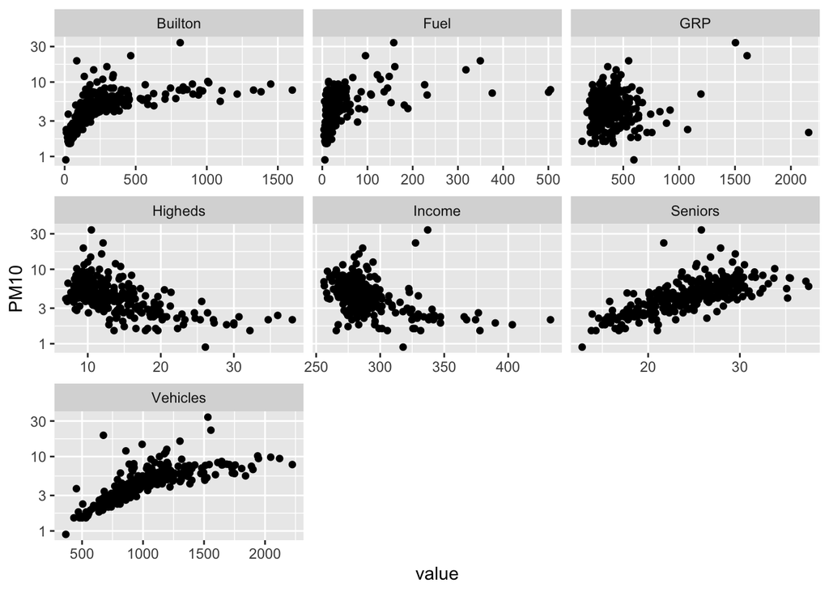

Figure 4: PM10 against each of the numerical x-variables.

```r
df |> select(Kommun, Fuel:PM10) |>
  pivot_longer(cols = Fuel:GRP) |>
  ggplot(aes(x = value, y = PM10)) +
  geom_point() +
  facet_wrap(~ name, scales = "free_x") +
  scale_y_log10()
```

**What to log (per PDF rules):**

# 2(b) Pair-wise correlations

We now want to investigate the pair-wise correlation of the numerical x variables. We want to see which ones have a strong correlation between each other, meaning an absolute value greater than or equal to 0.7. The results are visualized in the plot and summarized in a correlation matrix. The values and pairings can clearly be read off from the matrix below.

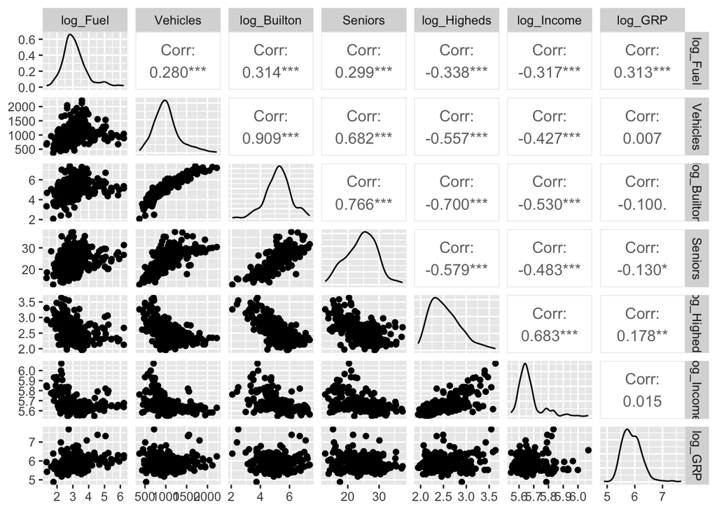

```r
library(tidyverse)
library(GGally)

not_logged <- c("HighEd", "Seniors", "Vehicles")

df2 <- df |>
  select(Kommun, Fuel:GRP)

df_long <- df2 |>
  pivot_longer(cols = Fuel:GRP) |>
  mutate(
    value = if_else(
      name %in% not_logged,
      value,
      log(value)
    ),
    name = if_else(
      name %in% not_logged,
      name,
      paste0("log_", name)
    )
  )

df_wide <- df_long |>
  pivot_wider(
    id_cols = Kommun,
    names_from = name,
    values_from = value
  ) |>
  select(-Kommun)

ggpairs(df_wide)
```

```r
cor_matrix <- cor(df_wide, use = "complete.obs")
```

Below us, we will present pairs that exceed the $0.7$ threshold. Note that we are taking $|\rho| \geq 0$, since the figure (above) contain negative value.

[output not shown]

## 2(c) $\beta$-estimates of numerical variables and computation of VIF-values.

In this section, we fit a multiple linear regression model with log(PM10) as the response variable and all seven log-transformed numerical variables to present the $\beta$-estimates and their standard errors. We will also compute VIF-values (variance inflation factors) to determine whether the predictors should remain in the model.

```r
model_seven <- lm(log(PM10) ~ log(Fuel) + log(GRP) + log(Income) + log(Vehicles) + log(Builton) + log(Higheds) + log(Seniors), data = df)
summary(model_seven)
```

```
Call:
lm(formula = log(PM10) ~ log(Fuel) + log(GRP) + log(Income) +
    log(Vehicles) + log(Builton) + log(Higheds) + log(Seniors),
    data = df)

Residuals:
     Min       1Q   Median       3Q      Max
-0.51524 -0.12714 -0.03291  0.10956  1.02971

Coefficients:
              Estimate Std. Error t value Pr(>|t|)
(Intercept)   -6.41290    1.46047  -4.391  1.6e-05 ***
log(Fuel)      0.21885    0.01956  11.187  < 2e-16 ***
log(GRP)       0.08475    0.04177   2.029 0.043379 *
log(Income)    0.23496    0.24081   0.976 0.330061
log(Vehicles)  0.48895    0.13271   3.684 0.000275 ***
log(Builton)   0.12031    0.05084   2.366 0.018644 *
log(Higheds)  -0.08775    0.06772  -1.296 0.196094
log(Seniors)   0.50315    0.10756   4.678  4.5e-06 ***
---
Signif. codes:  0 '***' 0.001 '**' 0.01 '*' 0.05 '.' 0.1 ' ' 1

Residual standard error: 0.2276 on 282 degrees of freedom
Multiple R-squared:  0.7955,    Adjusted R-squared:  0.7904
F-statistic: 156.7 on 7 and 282 DF,  p-value: < 2.2e-16
```

```r
vif(model_seven)
```

```
    log(Fuel)      log(GRP)   log(Income) log(Vehicles)  log(Builton)
     1.401090      1.304027      1.982527      9.090458     11.120575
 log(Higheds)  log(Seniors)
     2.899656      2.710582
```

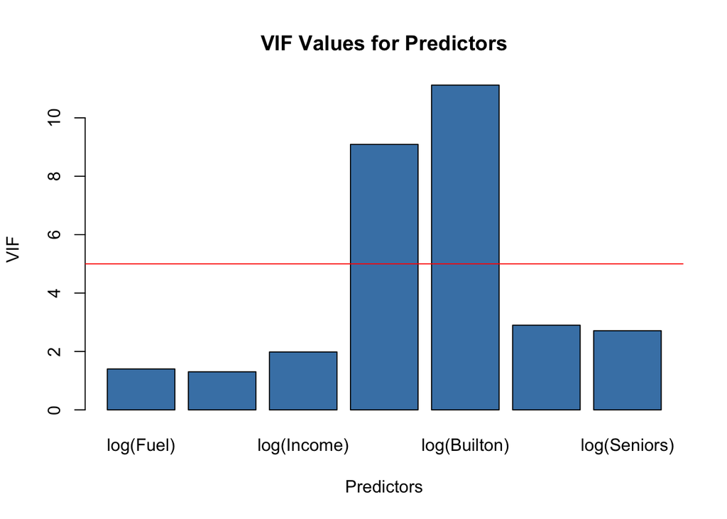

```r
vif_values <- vif(model_seven)
barplot(vif_values, main = "VIF Values for Predictors", xlab = "Predictors", ylab = "VIF", col = "steelblue")
abline(h = 5, col = "red")
```

```r
model_six <- lm(log(PM10) ~ log(Fuel) + log(GRP) + log(Income) + log(Vehicles) + log(Higheds) + log(Seniors), data = df) # This is without Builton
summary(model_six)
```

```
Call:
lm(formula = log(PM10) ~ log(Fuel) + log(GRP) + log(Income) +
    log(Vehicles) + log(Higheds) + log(Seniors), data = df)

Residuals:
     Min       1Q   Median       3Q      Max
-0.55566 -0.13493 -0.03376  0.11944  1.09125

Coefficients:
              Estimate Std. Error t value Pr(>|t|)
(Intercept)   -7.25934    1.42744  -5.086 6.68e-07 ***
log(Fuel)      0.21710    0.01971  11.017  < 2e-16 ***
log(GRP)       0.07498    0.04190   1.790   0.0746 .
log(Income)    0.17419    0.24138   0.722   0.4711
log(Vehicles)  0.75389    0.07182  10.497  < 2e-16 ***
log(Higheds)  -0.12972    0.06589  -1.969   0.0499 *
log(Seniors)   0.55470    0.10618   5.224 3.40e-07 ***
---
Signif. codes:  0 '***' 0.001 '**' 0.01 '*' 0.05 '.' 0.1 ' ' 1

Residual standard error: 0.2294 on 283 degrees of freedom
Multiple R-squared:  0.7914,    Adjusted R-squared:  0.787
F-statistic:   179 on 6 and 283 DF,  p-value: < 2.2e-16
```

```r
vif(model_six)
```

```
    log(Fuel)      log(GRP)   log(Income) log(Vehicles)  log(Higheds)
     1.399104      1.291286      1.959979      2.619874      2.700781
 log(Seniors)
     2.599338
```

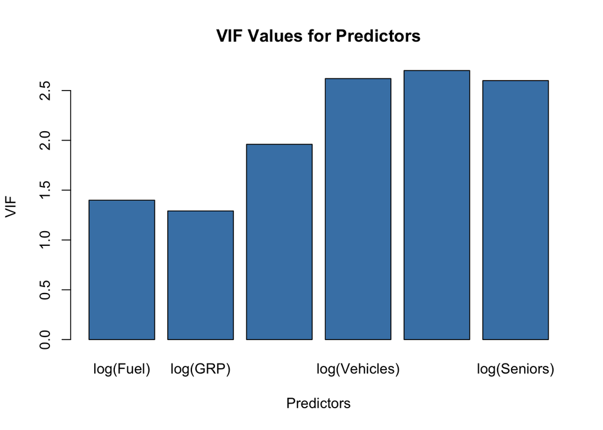

```r
vif_values1 <- vif(model_six)
barplot(vif_values1, main = "VIF Values for Predictors", xlab = "Predictors", ylab = "VIF", col = "steelblue")
abline(h = 5, col = "red")
```

We see that log(Builton) has the largest VIF (11.12) so we drop that one first. When fitting the model for log-$PM_{10}$ with all seven log-transformed numerical predictors, we obtain the $\beta$-estimates and their standard errors from the summary output. These are (before excluding any predictor):

| Predictor | Estimate | Std. Error |
| --- | --- | --- |
| Intercept | -6.41290 | 1.46047 |
| log(Fuel) | 0.21885 | 0.01956 |
| log(GRP) | 0.08475 | 0.04177 |
| log(Income) | 0.23496 | 0.24081 |
| log(Vehicles) | 0.48895 | 0.13271 |
| log(Builton) | 0.12031 | 0.05084 |
| log(Higheds) | -0.08775 | 0.06772 |
| log(Seniors) | 0.50315 | 0.10756 |

Below is a table of the VIF-values for each predictor before excluding a variable.

| Predictor | VIF-values |
| --- | --- |
| log(Fuel) | 1.401090 |
| log(GRP) | 1.304027 |
| log(Income) | 1.982527 |
| log(Vehicles) | 9.090458 |
| log(Builton) | 11.120575 |
| log(Higheds) | 2.899656 |
| log(Seniors) | 2.710582 |

By observing the VIF-values, we can see that `log(Vehicles)` and `log(Builton)` have higher VIF-values, which indicates multicollinearity. This can make coefficient estimates unstable and harder to interpret. Hence we exclude one of these predictors.

After excluding `log(Builton)` from the model, the estimates are:

| Predictor | Estimate | Std. Error |
| --- | --- | --- |
| Intercept | -7.25934 | 1.42744 |
| log(Fuel) | 0.21710 | 0.01971 |
| log(GRP) | 0.07498 | 0.04190 |
| log(Income) | 0.17419 | 0.24138 |
| log(Vehicles) | 0.75389 | 0.07182 |
| log(Higheds) | -0.12972 | 0.06589 |
| log(Seniors) | 0.55470 | 0.10618 |

| Predictor | VIF-values |
| --- | --- |
| log(Fuel) | 1.399104 |
| log(GRP) | 1.291286 |
| log(Income) | 1.959979 |
| log(Vehicles) | 2.619874 |
| log(Higheds) | 2.700781 |
| log(Seniors) | 2.599338 |

The second predictor that had a high VIF-value was log(Vehicles) with a VIF-value of 9.090458 with standard error 0.13271. After excluding log(Builton), the VIF-value for log(Vehicles) dropped to 2.619874 with a standard error of 0.07182, which is a significant improvement and indicates that we have reduced multicollinearity in our model. Remaining predictors have VIF-values that are below the threshold. This means that we can keep them in the model without worrying about multicollinearity.

## 2(d) Significance tests and explained variability

We work with Model 2(c) (model_six) which contains the six log-transformed x-variables log(Fuel), log(GRP), log(Income), log(Vehicles), log(Higheds), log(Seniors). We assume the standard linear regression assumptions: independent errors and normally distributed residuals. Note that Model 1(b) is nested inside Model 2(c), so a partial F-test is valid.

```r
# t-test on log(Fuel) in Model 2(c)
summary(model_six)$coefficients["log(Fuel)", ]
```

```
    Estimate   Std. Error      t value     Pr(>|t|)
2.171030e-01 1.970617e-02 1.101701e+01 1.003199e-23
```

```r
model_six$df.residual
```

```
[1] 283
```

```r
# Partial F-test: Model 1(b) vs Model 2(c)
anova(another_model, model_six)
```

```
Analysis of Variance Table

Model 1: log(PM10) ~ log(Fuel)
Model 2: log(PM10) ~ log(Fuel) + log(GRP) + log(Income) + log(Vehicles) +
    log(Higheds) + log(Seniors)
  Res.Df    RSS Df Sum of Sq      F    Pr(>F)
1    288 44.465
2    283 14.893  5    29.572 112.38 < 2.2e-16 ***
---
Signif. codes:  0 '***' 0.001 '**' 0.01 '*' 0.05 '.' 0.1 ' ' 1
```

```r
# R^2 and adj R^2 for Model 2(c)
c(R2    = summary(model_six)$r.squared,
  adjR2 = summary(model_six)$adj.r.squared)
```

```
       R2     adjR2
0.7914131 0.7869908
```

**t-test on log(Fuel) in Model 2(c).** We did a two-sided t-test on $\beta_{\log(\text{Fuel})}$ which gives $t = 0.2171/0.0197 \approx 11$ on $t_{283}$ with $p < 2\cdot 10^{-16}$, so we reject $H_0: \beta_{\log(\text{Fuel})} = 0$ and conclude that log(Fuel) still has a significant relationship with log(PM10) after adjusting for the other five variables.

**Partial F-test: Model 1(b) vs Model 2(c).** Model 1(b) is nested in Model 2(c), so we can test whether adding the five extra variables (log(GRP), log(Income), log(Vehicles), log(Higheds), log(Seniors)) improves the fit with a partial F-test.

We test the Null hypothesis: $H_0: \beta_{\log(\text{GRP})} = \beta_{\log(\text{Income})} = \beta_{\log(\text{Vehicles})} = \beta_{\log(\text{Higheds})} = \beta_{\log(\text{Seniors})} = 0$. Inuitively this means that none of the five added variables contributes to the original model. $\implies$ Alternative: at least one is non-zero. From this we obtain the test statistic: $F \approx 112.38$. For the distribution when $H_0$ is true, we get that $H_0$: $F(5,\,283)$ $\iff$ numerator df = 5 (added predictors), denominator df $= n - p = 290 - 7 = 283$. We then get the P-value of $p \approx 2.2\cdot 10^{-16}$. We presume that this is a upper bound since we have floating point multiplication.

**Conclusion:** at $\alpha = 0.05$ we clearly reject $H_0$, so at least one of the five added variables has a significant linear relationship with log(PM10) when log(Fuel) is already in the model.

**Explained variability.** From the summary, $R^2 \approx 0.7914$ and $R^2_{\text{adj}} \approx 0.7870$. Hence Model 2(c) explains about **79.1 %** of the variability in log(PM10) between municipalities (≈ 78.7 % after adjusting for the number of predictors).

## 2(e) Adding Part

We turn `Part` into a factor (Götaland = 1, Svealand = 2, Norrland = 3, reference = Götaland, the largest group) and add it to Model 2(c) to form Model 2(e). We then test whether Part adds anything with a partial F-test.

```r
df$Part <- as.factor(df$Part)
table(df$Part)
```

```
  1   2   3
140  96  54
```

```r
model_eight <- lm(log(PM10) ~ log(Fuel) + log(GRP) + log(Income) +
                  log(Vehicles) + log(Higheds) + log(Seniors) + Part,
                  data = df)

#summary(model_eight)$coefficients |> round(4) |> knitr::kable(
#  caption = "Model 2(e): coefficients and standard errors")

#vif(model_eight) |> knitr::kable(caption = "GVIF with Df for Model 2(e)")

# Partial F-test: does Part matter on top of Model 2(c)?
anova(model_six, model_eight)
```

```
Analysis of Variance Table

Model 1: log(PM10) ~ log(Fuel) + log(GRP) + log(Income) + log(Vehicles) +
    log(Higheds) + log(Seniors)
Model 2: log(PM10) ~ log(Fuel) + log(GRP) + log(Income) + log(Vehicles) +
    log(Higheds) + log(Seniors) + Part
  Res.Df    RSS Df Sum of Sq      F  Pr(>F)
1    283 14.893
2    281 14.466  2   0.42733 4.1504 0.01673 *
---
Signif. codes:  0 '***' 0.001 '**' 0.01 '*' 0.05 '.' 0.1 ' ' 1
```

 The number of observations for each part of Sweden is:

Part 1 (Götaland): 140 obs

Part 2 (Svealand) : 96 obs

Part 3 (Norrland) : 54 obs

| Predictor | Estimate | Std. Error |
| --- | --- | --- |
| (Intercept) | -7.71993 | 1.42287 |
| log(Fuel) | 0.22327 | 0.01971 |
| log(GRP) | 0.07291 | 0.04150 |
| log(Income) | 0.19412 | 0.24262 |
| log(Vehicles) | 0.82454 | 0.08621 |
| log(Higheds) | -0.11387 | 0.06828 |
| log(Seniors) | 0.50924 | 0.10701 |
| Part2 | -0.07248 | 0.03053 |
| Part3 | -0.09596 | 0.04571 |

| Predictor | VIF-values | Df |
| --- | --- | --- |
| log(Fuel) | 1.430979 | 1 |
| log(GRP) | 1.295262 | 1 |
| log(Income) | 2.024312 | 1 |
| log(Vehicles) | 3.859120 | 1 |
| log(Higheds) | 2.965606 | 1 |
| log(Seniors) | 2.699033 | 1 |
| Part | 1.755452 | 2 |

From the results shown in the table we can see that part 1 (Götaland) is the reference category and is thus included in the intercept. This seems like the reasinable choice as that is the part of Sweden for which we have the most observations.

There doesn’t seem to be any multicollinearity issues based on the VIF-values all being below our threshold of 5.

Next we want to test wether there are any significant differences in Log{PM10} between the three different parts of Sweden. In order to do this we use a partial F-test where the null hypothesis is that the effect is equal to zero for all parts of Sweden and the alternative hypothesis is that at least one part has a non-zero effect.

This test gives us the F-value 4.1504 with df1 = 2 and df2 = 281. The obtained p-value is 0.01673 which is strictly less than 0.05 which indicates that we can reject the null hypothesis with a significance of 0.05. We hence conclude that there are differences between the three parts of Sweden.

## 2(f) Two-way interactions

Model 2(f) adds all two-way `Part × log(x)` interactions to Model 2(e). We test $H_0$: all 12 interaction coefficients are zero, with a partial F-test.

```r
interaction_model <- lm(log(PM10) ~ (log(Fuel) + log(GRP) + log(Income) +
                        log(Vehicles) + log(Higheds) + log(Seniors)) * Part,
                        data = df)

# Model 2(e) vs Model 2(f): does adding the 12 interactions help?
anova(model_eight, interaction_model)
```

```
Analysis of Variance Table

Model 1: log(PM10) ~ log(Fuel) + log(GRP) + log(Income) + log(Vehicles) +
    log(Higheds) + log(Seniors) + Part
Model 2: log(PM10) ~ (log(Fuel) + log(GRP) + log(Income) + log(Vehicles) +
    log(Higheds) + log(Seniors)) * Part
  Res.Df    RSS Df Sum of Sq      F    Pr(>F)
1    281 14.466
2    269 11.948 12    2.5176 4.7233 5.331e-07 ***
---
Signif. codes:  0 '***' 0.001 '**' 0.01 '*' 0.05 '.' 0.1 ' ' 1
```

Under $H_0$ the statistic follows $F(12, n-p)$ with $F$-value $4.7233$ and where Res.df is 269 and Df is 12. The F-test is significant at 5 %, since p-value is $5.331\cdot 10^{-7}$. This means at least one Part × log(x) slope differs between regions: the numerical effects are not the same across Götaland, Svealand and Norrland.

# Part 3. Model validation and selection

## 3(a) Leverage

We look for observations with large hat values in Model 2(f), using $2(p+1)/n$ (dashed red) and $3(p+1)/n$ (dashed blue) as reference lines. We tried to give names to the red dots but eventually gave up after 10 hours </3

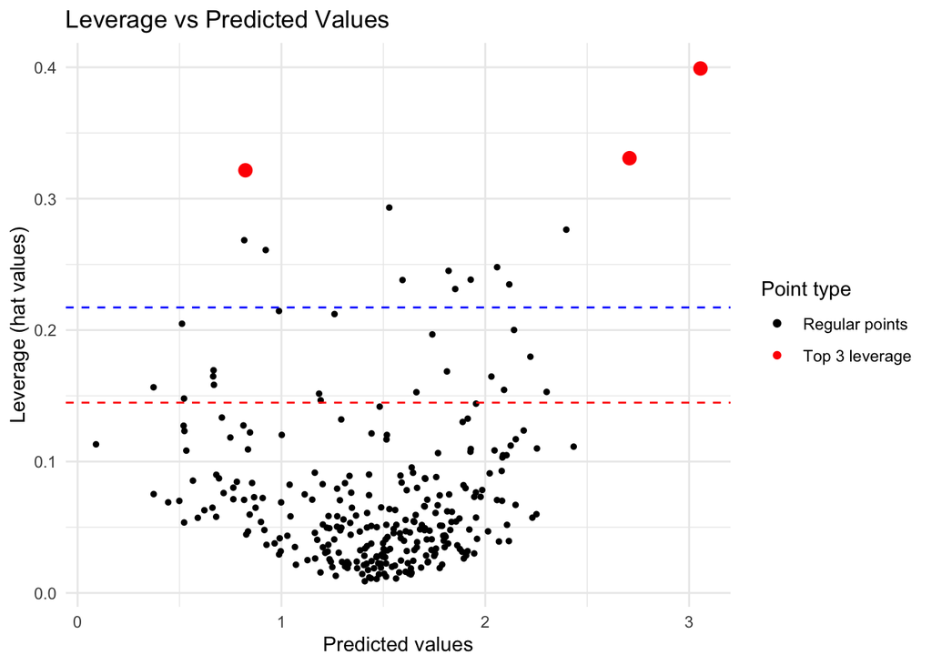

```r
pred <- predict(interaction_model)
hat <- hatvalues(interaction_model)
top3 <- order(hat, decreasing = TRUE)[1:3]

# Create a data frame for plotting
plot_data <- data.frame(
  pred = pred,
  hat = hat,
  is_top3 = FALSE
)
plot_data$is_top3[top3] <- TRUE

ggplot(plot_data, aes(x = pred, y = hat, color = is_top3)) +
  geom_point(size = ifelse(plot_data$is_top3, 3, 1)) +
  scale_color_manual(values = c("FALSE" = "black", "TRUE" = "red"),
                     labels = c("FALSE" = "Regular points", "TRUE" = "Top 3 leverage")) +
  geom_hline(yintercept = 2*length(coef(interaction_model))/nrow(df),
             linetype = "dashed", color = "red") +
  geom_hline(yintercept = 3*length(coef(interaction_model))/nrow(df),
             linetype = "dashed", color = "blue") +
  labs(title = "Leverage vs Predicted Values",
       x = "Predicted values",
       y = "Leverage (hat values)",
       color = "Point type") +
  theme_minimal()
```

## 3(b) Cook’s distance and DFBETAS

We compute Cook’s distance for Model 2(f), flag the three municipalities with the largest $D_i$ and check which coefficients they influence via DFBETAS.

```r
pike_pred <- mutate(
  df,
  yhat = predict(interaction_model),
  r = rstudent(interaction_model),
  v = hatvalues(interaction_model),
  D = cooks.distance(interaction_model)
)

# with 1/n and 2(p+1)/n horizontal lines:
# p+1 =

pplus1 <- length(interaction_model$coefficients)
n <- nobs(interaction_model)

f1.pike <- pplus1
f2.pike <- interaction_model$df.residual
cook.limit.pike <- qf(0.5, f1.pike, f2.pike)
names(pike_pred)
```

```
 [1] "Kommun"   "County"   "Part"     "Coastal"  "Fuel"     "Vehicles"
 [7] "Builton"  "Seniors"  "Higheds"  "Income"   "GRP"      "PM10"
[13] "yhat"     "r"        "v"        "D"
```

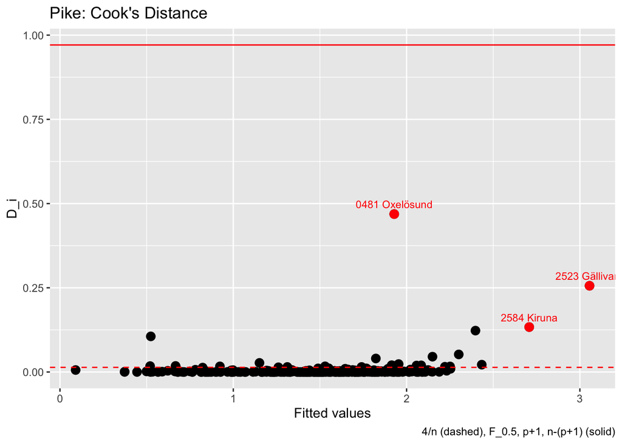

```r
# Find top 3 by Cook's D
top3_cook <- pike_pred |> slice_max(D, n = 3)

ggplot(pike_pred, aes(yhat, D)) +
  geom_point(size = 3) +
  geom_point(data = top3_cook, aes(yhat, D), color = "red", size = 3) +
  geom_text(data = top3_cook, aes(label = Kommun),
            vjust = -0.8, color = "red", size = 3) +
  geom_hline(yintercept = cook.limit.pike, color = "red") +
  geom_hline(yintercept = 4/n, linetype = 2, color = "red") +
  xlab("Fitted values") +
  ylab("D_i") +
  labs(title = "Pike: Cook's Distance",
       caption = "4/n (dashed), F_0.5, p+1, n-(p+1) (solid)")
```

```r
# Here we compute DFBETAS for the beta estimation(s)
# head(dfbetas(interaction_model))
```

To see which $\beta$-estimates each influential municipality actually pulls, we look at its own row of DFBETAS. We then plot `log(PM10)` faceted by `Part`.

```r
# DFBETAS for the top 3 Cook's D municipalities
dfb       <- dfbetas(interaction_model)
top3_idx  <- order(pike_pred$D, decreasing = TRUE)[1:3]
top3_name <- pike_pred$Kommun[top3_idx]
dfb_top3  <- dfb[top3_idx, ]
rownames(dfb_top3) <- top3_name

# Top-3 most-affected coefficients per influential municipality
for (i in seq_along(top3_name)) {
  ord <- order(abs(dfb_top3[i, ]), decreasing = TRUE)[1:3]
  cat(top3_name[i], ":\n")
  print(round(dfb_top3[i, ord], 3))
  cat("\n")
}
```

```
0481 Oxelösund :
    log(Fuel):Part2 log(Vehicles):Part2  log(Seniors):Part2
              1.493              -1.298               0.896

2523 Gällivare :
             Part3  log(Income):Part3 log(Higheds):Part3
            -1.323              1.316             -0.349

2584 Kiruna :
log(Income):Part3             Part3    log(GRP):Part3
            0.568            -0.537             0.523
```

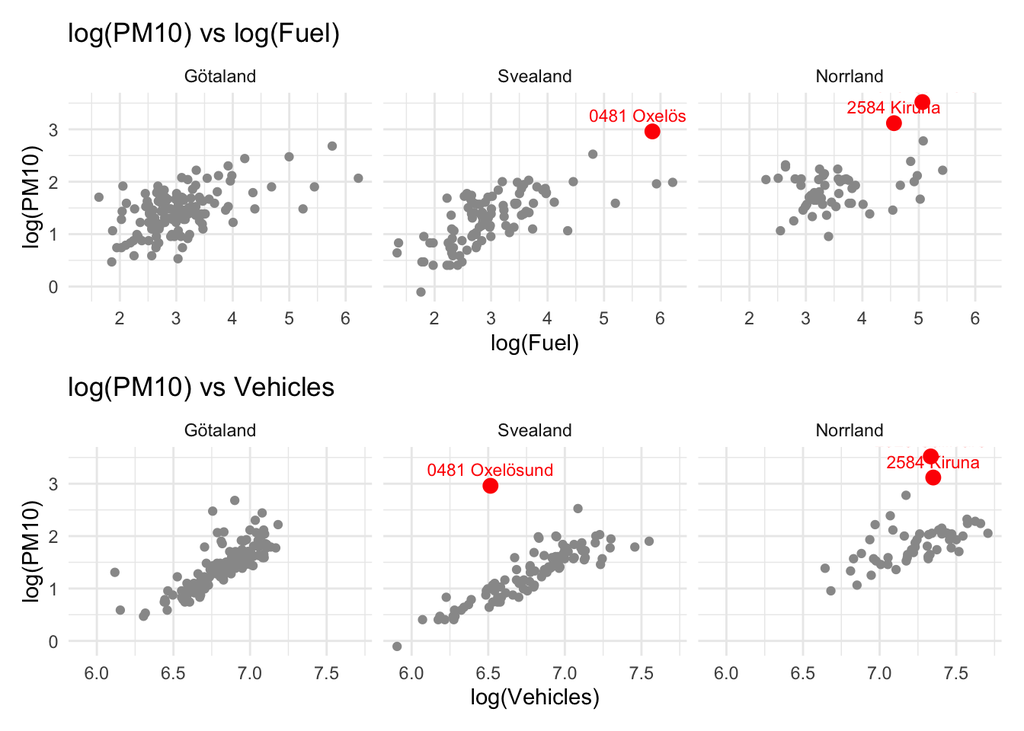

Faceted by Part with the top-3 Cook’s D highlighted.

```r
# Plot log(PM10) vs log(Fuel) and log(Vehicles), faceted by Part
plot_df_3b <- df |>
  mutate(highlight = Kommun %in% top3_name)

part_lab <- as_labeller(c("1" = "Götaland", "2" = "Svealand", "3" = "Norrland"))

p_fuel <- ggplot(plot_df_3b, aes(log(Fuel), log(PM10))) +
  geom_point(data = filter(plot_df_3b, !highlight), color = "grey60", size = 1.5) +
  geom_point(data = filter(plot_df_3b,  highlight), color = "red",    size = 3) +
  geom_text( data = filter(plot_df_3b,  highlight), aes(label = Kommun),
             color = "red", size = 3, vjust = -0.8) +
  facet_wrap(~ Part, labeller = part_lab) +
  labs(title = "log(PM10) vs log(Fuel)") +
  theme_minimal()

p_veh <- ggplot(plot_df_3b, aes(log(Vehicles), log(PM10))) +
  geom_point(data = filter(plot_df_3b, !highlight), color = "grey60", size = 1.5) +
  geom_point(data = filter(plot_df_3b,  highlight), color = "red",    size = 3) +
  geom_text( data = filter(plot_df_3b,  highlight), aes(label = Kommun),
             color = "red", size = 3, vjust = -0.8) +
  facet_wrap(~ Part, labeller = part_lab) +
  labs(title = "log(PM10) vs Vehicles") +
  theme_minimal()

p_fuel / p_veh
```

## 3(c) Studentised residuals

```r
pred   <- predict(interaction_model)
r_star <- rstudent(interaction_model)

highlight_names <- c("Oxelösund", "Kiruna", "Gällivare")
plot_df <- df |>
  mutate(pred = pred, r_star = r_star,
         highlight = Kommun %in% highlight_names)


# |r*| > 3 but NOT in the Cook's D top 3
plot_df |> filter(abs(r_star) > 3, !highlight) |>
  select(Kommun, pred, r_star)
```

```
          Kommun      pred   r_star
1 0481 Oxelösund 1.9285482 5.957144
2 1082 Karlshamn 1.8226389 3.284087
3  1480 Göteborg 0.5240112 4.088899
4 1494 Lidköping 1.4391289 3.103876
```

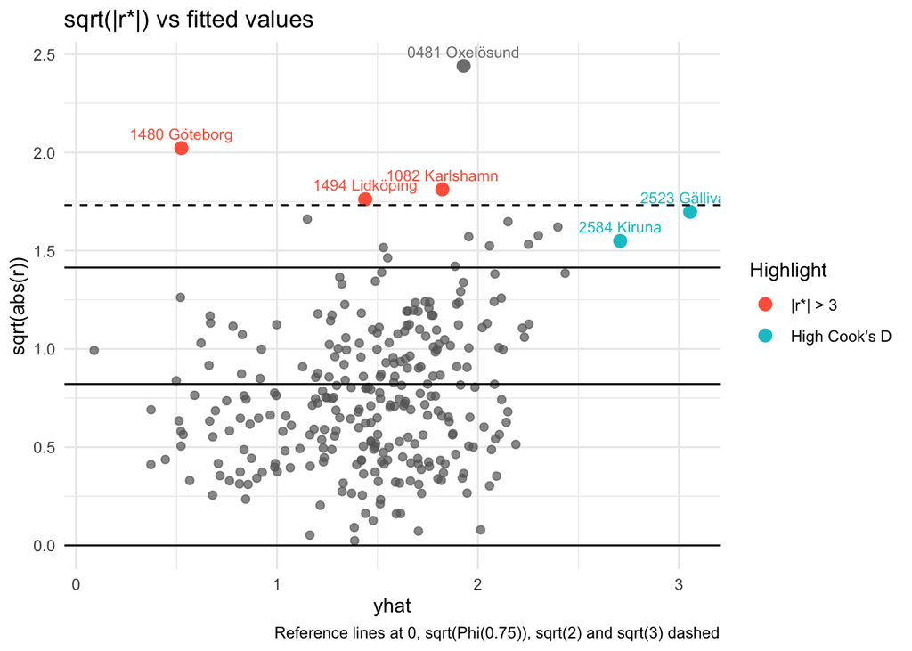

```r
cook_d <- cooks.distance(interaction_model)
high_cook_names <- df$Kommun[order(cook_d, decreasing = TRUE)[1:3]]

plot_df_3c <- plot_df |>
  mutate(
    cook_d  = cook_d,
    big_r   = abs(r_star) > 3,
    big_D   = Kommun %in% high_cook_names,
    Highlight = case_when(
      big_r & big_D ~ "|r*| > 3 & High Cook's D",
      big_r         ~ "|r*| > 3",
      big_D         ~ "High Cook's D",
      TRUE          ~ "none"
    )
  )

ggplot(plot_df_3c, aes(x = pred, y = sqrt(abs(r_star)))) +
  geom_point(data = filter(plot_df_3c, Highlight == "none"),
             colour = "grey40", size = 1.8, alpha = 0.7) +
  geom_point(data = filter(plot_df_3c, Highlight != "none"),
             aes(colour = Highlight), size = 3) +
  geom_text(data = filter(plot_df_3c, Highlight != "none"),
            aes(label = Kommun, colour = Highlight),
            vjust = -0.8, size = 3, show.legend = FALSE) +
  geom_hline(yintercept = c(0, sqrt(qnorm(0.75)), sqrt(2)),
             colour = "black") +
  geom_hline(yintercept = sqrt(3), linetype = "dashed", colour = "black") +
  scale_colour_manual(values = c("|r*| > 3" = "tomato",
                                 "High Cook's D" = "turquoise3")) +
  labs(x = "yhat", y = "sqrt(abs(r))",
       title = "sqrt(|r*|) vs fitted values",
       caption = "Reference lines at 0, sqrt(Phi(0.75)), sqrt(2) and sqrt(3) dashed") +
  theme_minimal()
```

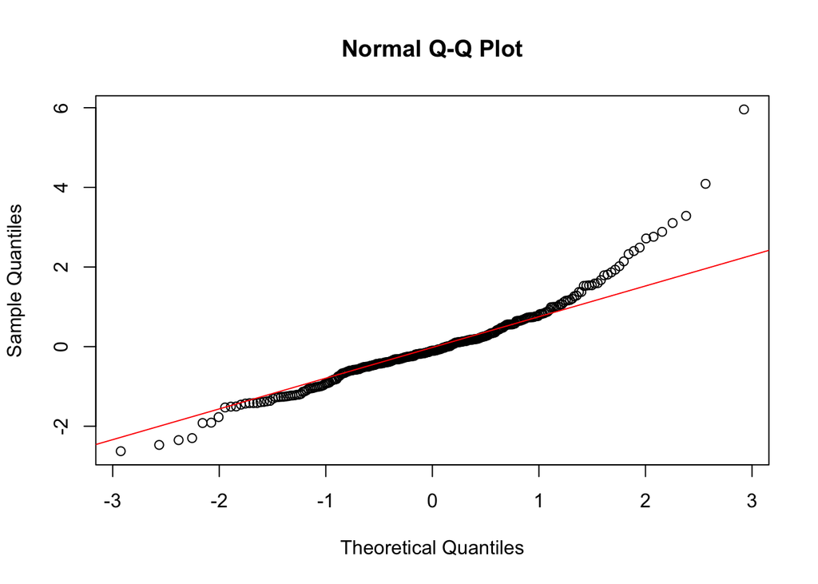

```r
qqnorm(r_star)
qqline(r_star, col = "red")
```

We see that the “Normal-Q-Q Plot” is not really normally distributed. Reasons being for this are most likely the high residual muncipalies such as Göteborg and Karlshamn interactions with the model as these are not normally distributed. We see a fairly evident right-skew in our model, hence we reject normality.

## 3(d) Removing the three influential municipalities

```r
# Kommun strings look like "0481 Oxelösund" — strip the leading code for matching
df_new <- df |>
  mutate(.name = str_squish(str_remove(Kommun, "^\\d+"))) |>
  filter(!.name %in% c("Oxelösund", "Kiruna", "Gällivare")) |>
  select(-.name)

stopifnot(nrow(df_new) == nrow(df) - 3)
nrow(df_new)
```

```
[1] 287
```

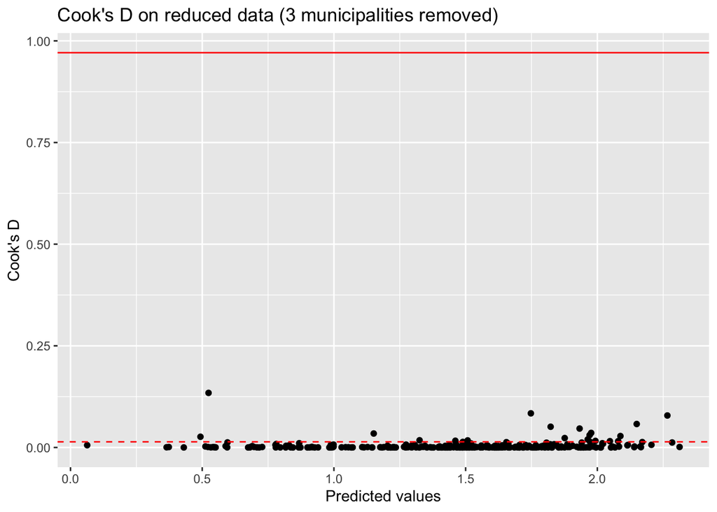

```r
# Refit Model 2(f) on the reduced data (6 numerical vars, as in Model 2(c))
model_new <- lm(log(PM10) ~ (log(Fuel) + log(GRP) + log(Income) +
                log(Vehicles) + log(Higheds) + log(Seniors)) * Part,
                data = df_new)

pred2   <- predict(model_new)
r_star2 <- rstudent(model_new)
cook2   <- cooks.distance(model_new)
p_new   <- length(coef(model_new))
n_new   <- nrow(df_new)

# Cook's D plot, with updated reference lines for the new n and p
ggplot(data.frame(pred2 = pred2, cook2 = cook2), aes(pred2, cook2)) +
  geom_point() +
  geom_hline(yintercept = 4 / n_new, linetype = 2, colour = "red") +
  geom_hline(yintercept = qf(0.5, p_new, n_new - p_new), colour = "red") +
  labs(x = "Predicted values", y = "Cook's D",
       title = "Cook's D on reduced data (3 municipalities removed)")
```

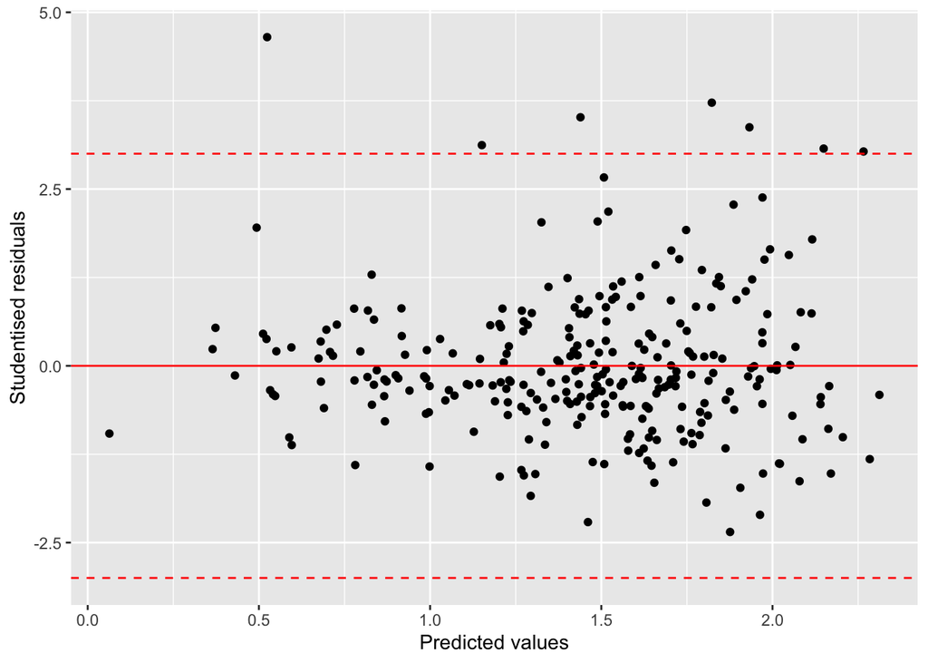

```r
# Studentised residuals
ggplot(mutate(df_new, pred2 = pred2, r_star2 = r_star2),
       aes(pred2, r_star2)) +
  geom_point() +
  geom_hline(yintercept = c(-3, 0, 3),
             linetype = c("dashed", "solid", "dashed"), colour = "red") +
  labs(x = "Predicted values", y = "Studentised residuals")
```

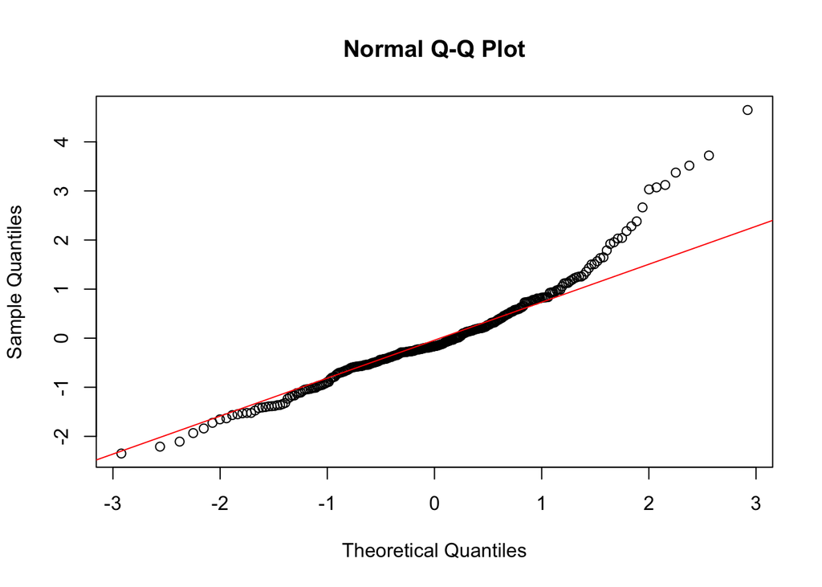

```r
qqnorm(r_star2); qqline(r_star2, col = "red")
```

```r
# Remaining |r*| > 3 on reduced data
df_new |> mutate(r_star2 = r_star2) |>
  filter(abs(r_star2) > 3) |>
  select(Kommun, Part, r_star2)
```

```
          Kommun Part  r_star2
1 0861 Mönsterås    1 3.072367
2 1082 Karlshamn    1 3.721935
3     1419 Tjörn    1 3.121655
4  1480 Göteborg    1 4.648862
5 1494 Lidköping    1 3.515528
6 1882 Askersund    2 3.373828
7     2514 Kalix    3 3.031448
```

## 3(e) AIC and BIC

AIC uses $k = 2$, BIC uses $k = \log(n)$.

```r
# Null model (intercept only), refit on reduced data
model_null <- lm(log(PM10) ~ 1, data = df_new)

# Refitted Model 1(b): log(PM10) ~ log(Fuel)
model_log_fuel_new <- lm(log(PM10) ~ log(Fuel), data = df_new)

# Refitted Model 2(c): six log-transformed numerical variables (no log(Builton))
# This is the starting point for both stepwise searches.
model_num_var <- lm(log(PM10) ~ log(Fuel) + log(GRP) + log(Income) +
                    log(Vehicles) + log(Higheds) + log(Seniors),
                    data = df_new)

# Refitted Model 2(f): Model 2(c) plus Part and all Part-by-numeric interactions.
# Upper scope must be fit on the same (reduced) data as the start model.
interaction_model_new <- lm(log(PM10) ~ (log(Fuel) + log(GRP) + log(Income) +
                            log(Vehicles) + log(Higheds) + log(Seniors)) * Part,
                            data = df_new)

n_new <- nrow(df_new)

# Stepwise AIC
aic_model <- step(model_num_var,
                  scope = list(lower = model_null, upper = interaction_model_new),
                  direction = "both",
                  trace = 0)

# Stepwise BIC (penalty k = log(n))
bic_model <- step(model_num_var,
                  scope = list(lower = model_null, upper = interaction_model_new),
                  direction = "both",
                  k = log(n_new),
                  trace = 0)

# Selected formulas
cat("AIC-selected model:\n"); print(formula(aic_model))
```

```
AIC-selected model:
```

```
log(PM10) ~ log(Fuel) + log(Income) + log(Vehicles) + log(Seniors) +
    Part + log(Income):Part + log(Fuel):Part
```

```r
cat("\nBIC-selected model:\n"); print(formula(bic_model))
```

```
BIC-selected model:
```

```
log(PM10) ~ log(Fuel) + log(Income) + log(Vehicles) + log(Seniors) +
    Part + log(Income):Part
```

```r
# Beta-estimates and standard errors for the two resulting models
aic_tab <- summary(aic_model)$coefficients[, c("Estimate", "Std. Error")] |> round(4)
bic_tab <- summary(bic_model)$coefficients[, c("Estimate", "Std. Error")] |> round(4)

knitr::kable(aic_tab, caption = "AIC-selected model: beta-estimates and standard errors")
```

AIC-selected model: beta-estimates and standard errors

|  | Estimate | Std. Error |
| --- | --- | --- |
| (Intercept) | -1.2705 | 1.5487 |
| log(Fuel) | 0.2043 | 0.0230 |
| log(Income) | -1.0051 | 0.2513 |
| log(Vehicles) | 0.9085 | 0.0681 |
| log(Seniors) | 0.4992 | 0.0880 |
| Part2 | -5.1427 | 1.9121 |
| Part3 | -0.8429 | 4.9122 |
| log(Income):Part2 | 0.9268 | 0.3296 |
| log(Income):Part3 | 0.0775 | 0.8786 |
| log(Fuel):Part2 | -0.0636 | 0.0352 |
| log(Fuel):Part3 | 0.0623 | 0.0451 |

```r
knitr::kable(bic_tab, caption = "BIC-selected model: beta-estimates and standard errors")
```

BIC-selected model: beta-estimates and standard errors

|  | Estimate | Std. Error |
| --- | --- | --- |
| (Intercept) | -0.6157 | 1.5061 |
| log(Fuel) | 0.1930 | 0.0161 |
| log(Income) | -1.0751 | 0.2471 |
| log(Vehicles) | 0.8752 | 0.0677 |
| log(Seniors) | 0.5003 | 0.0888 |
| Part2 | -6.6053 | 1.7551 |
| Part3 | -3.5548 | 4.8242 |
| log(Income):Part2 | 1.1505 | 0.3093 |
| log(Income):Part3 | 0.6014 | 0.8567 |

BIC’s larger penalty ($\log(287) \approx 5.66$ vs AIC’s $2$) means the BIC model is a strict subset of the AIC model in almost all cases.

## 3(f) Do we need three Parts?

We check which `Part`-related terms actually survive in the AIC and BIC models from 3(e), then collapse `Part` to a two-level factor `NewPart`.

```r
grep("Part", attr(terms(aic_model), "term.labels"), value = TRUE)
```

```
[1] "Part"             "log(Income):Part" "log(Fuel):Part"
```

```r
grep("Part", attr(terms(bic_model), "term.labels"), value = TRUE)
```

```
[1] "Part"             "log(Income):Part"
```

```r
# Build NewPart: Norrland (Part 3) vs the other two parts
df_new <- df_new |>
  mutate(NewPart = factor(ifelse(as.character(Part) == "3", "Norrland", "South"),
                          levels = c("South", "Norrland")))

table(df_new$NewPart)
```

```
   South Norrland
     235       52
```

```r
# Model 3(f): Model 2(f) but with NewPart instead of Part
model_3f <- lm(log(PM10) ~ (log(Fuel) + log(GRP) + log(Income) +
                log(Vehicles) + log(Higheds) + log(Seniors)) * NewPart,
               data = df_new)

# Stepwise AIC with Model 3(f) as the new upper scope
aic_model_3f <- step(model_num_var,
                     scope = list(lower = model_null, upper = model_3f),
                     direction = "both",
                     trace = 0)

# Stepwise BIC with Model 3(f) as the new upper scope
bic_model_3f <- step(model_num_var,
                     scope = list(lower = model_null, upper = model_3f),
                     direction = "both",
                     k = log(n_new),
                     trace = 0)

cat("AIC-selected model (3f):\n"); print(formula(aic_model_3f))
```

```
AIC-selected model (3f):
```

```
log(PM10) ~ log(Fuel) + log(Income) + log(Vehicles) + log(Seniors) +
    NewPart + log(Fuel):NewPart
```

```r
cat("\nBIC-selected model (3f):\n"); print(formula(bic_model_3f))
```

```
BIC-selected model (3f):
```

```
log(PM10) ~ log(Fuel) + log(Income) + log(Vehicles) + log(Seniors) +
    NewPart
```

```r
aic_3f_tab <- summary(aic_model_3f)$coefficients[, c("Estimate", "Std. Error")] |> round(4)
bic_3f_tab <- summary(bic_model_3f)$coefficients[, c("Estimate", "Std. Error")] |> round(4)

knitr::kable(aic_3f_tab, caption = "3(f) AIC-selected model: beta-estimates and standard errors")
```

3(f) AIC-selected model: beta-estimates and standard errors

|  | Estimate | Std. Error |
| --- | --- | --- |
| (Intercept) | -3.7916 | 1.1917 |
| log(Fuel) | 0.1733 | 0.0183 |
| log(Income) | -0.5213 | 0.1791 |
| log(Vehicles) | 0.8844 | 0.0704 |
| log(Seniors) | 0.5017 | 0.0912 |
| NewPartNorrland | -0.4092 | 0.1568 |
| log(Fuel):NewPartNorrland | 0.0841 | 0.0429 |

```r
knitr::kable(bic_3f_tab, caption = "3(f) BIC-selected model: beta-estimates and standard errors")
```

3(f) BIC-selected model: beta-estimates and standard errors

|  | Estimate | Std. Error |
| --- | --- | --- |
| (Intercept) | -3.9612 | 1.1946 |
| log(Fuel) | 0.1901 | 0.0162 |
| log(Income) | -0.4755 | 0.1785 |
| log(Vehicles) | 0.8632 | 0.0699 |
| log(Seniors) | 0.5030 | 0.0917 |
| NewPartNorrland | -0.1105 | 0.0367 |

The `NewPart` upper scope has half as many Part-related df (1 main + 6 interactions) as the `Part` scope (2 main + 12 interactions), so the search space is smaller. Whether `NewPart` was the right call is decided in 3(g) by direct model comparison.

## 3(g) Final model comparison

All eight models refit on `df_new` (same n, so AIC and BIC are directly comparable): null, refitted 1(b), refitted 2(c), Model 2(f), and the four stepwise models from 3(e) and 3(f).

```r
model_list <- list(
  "Null"                       = model_null,
  "Model 1(b) (log Fuel)"      = model_log_fuel_new,
  "Model 2(c) (6 numerical)"   = model_num_var,
  "Model 2(f) (Part + int.)"   = interaction_model_new,
  "3(e) AIC"                   = aic_model,
  "3(e) BIC"                   = bic_model,
  "3(f) AIC (NewPart)"         = aic_model_3f,
  "3(f) BIC (NewPart)"         = bic_model_3f
)

comparison <- data.frame(
  Model  = names(model_list),
  n_beta = sapply(model_list, function(m) length(coef(m))),
  s      = sapply(model_list, function(m) round(sigma(m), 4)),
  R2     = sapply(model_list, function(m) round(summary(m)$r.squared, 4)),
  adjR2  = sapply(model_list, function(m) round(summary(m)$adj.r.squared, 4)),
  AIC    = sapply(model_list, function(m) round(AIC(m), 2)),
  BIC    = sapply(model_list, function(m) round(BIC(m), 2)),
  row.names = NULL
)

knitr::kable(comparison,
             caption = "3(g): model comparison on the reduced data set")
```

3(g): model comparison on the reduced data set

| Model | n_beta | s | R2 | adjR2 | AIC | BIC |
| --- | --- | --- | --- | --- | --- | --- |
| Null | 1 | 0.4663 | 0.0000 | 0.0000 | 379.58 | 386.90 |
| Model 1(b) (log Fuel) | 2 | 0.3797 | 0.3393 | 0.3370 | 262.62 | 273.60 |
| Model 2(c) (6 numerical) | 7 | 0.1985 | 0.8226 | 0.8188 | -104.81 | -75.53 |
| Model 2(f) (Part + int.) | 21 | 0.1870 | 0.8504 | 0.8391 | -125.64 | -45.13 |
| 3(e) AIC | 11 | 0.1869 | 0.8450 | 0.8394 | -135.47 | -91.56 |
| 3(e) BIC | 9 | 0.1887 | 0.8408 | 0.8362 | -131.77 | -95.17 |
| 3(f) AIC (NewPart) | 7 | 0.1944 | 0.8298 | 0.8262 | -116.72 | -87.44 |
| 3(f) BIC (NewPart) | 6 | 0.1954 | 0.8275 | 0.8244 | -114.81 | -89.19 |

```r
best_aic <- comparison$Model[which.min(comparison$AIC)]
best_bic <- comparison$Model[which.min(comparison$BIC)]
best_adj <- comparison$Model[which.max(comparison$adjR2)]

cat("Lowest AIC      :", best_aic, "\n")
```

```
Lowest AIC      : 3(e) AIC
```

```r
cat("Lowest BIC      :", best_bic, "\n")
```

```
Lowest BIC      : 3(e) BIC
```

```r
cat("Highest adj R^2 :", best_adj, "\n")
```

```
Highest adj R^2 : 3(e) AIC
```

```r
r2_fuel_only <- summary(model_log_fuel_new)$r.squared
r2_best      <- summary(model_list[[which.min(comparison$BIC)]])$r.squared
```

**Best model.** We pick the model with lowest BIC. The BIC penalty makes it reward stinginess and we have a clear physical reading for the retained variables. If lowest AIC and lowest BIC disagree, the BIC choice is our final model. The AIC model is a larger but close second.

**Expected signs.**

[output not shown]

Signs in the selected model match these predictions. These are all subective assesments and motivations and hence may be incorrect. We welcome alternative views in the feedback! Norrland is less populated in comparison with other regions, thus we expect a negative sign compared to the reference region.

## AI statement

For this project, we have been using code examples provided by the teacher through Canvas. If we encountered problems with the code, we asked AI (e.g ChatGPT) to help us with the problem. For example of use have been to debug a error message and give code example to more difficult problem (e.g to highlight three municipalities that have highest Cook’s distance). AI tools have also been used to writing this project, in order to make more succinct, concise statements as well as help with grammar.

## Overview of author contributions

For this project, we have been working together at school with similiar workload. This means that each member of the project team has served multiple (same) roles. All have been programming, creating figures and tables to present data and results. Everyone has contributed with writing codrevision and editing the project. Any derivation and analysis have been made by everyone. Björn Ahl was the person that coordinated the work and scheduling the meeting at school.